# who-data-analysis

### About dataset: A compilation of a set of social, economic, health, and political indicators using data from the World Health Organization and partner organizations.

```python
import pandas as pd
import seaborn as sns
import numpy as np
from matplotlib import pyplot as plt
from matplotlib.colors import ListedColormap

%matplotlib inline
```

#### Loading the dataset

```python
df = pd.read_csv("../input/WHO.csv")
pd.set_option('display.max_rows', 500) #Default Maximum rows to be displayed is set to 500
pd.set_option('display.max_columns',500) #Default Maximum columns to be displayed is set to 500
df.head()
```

|  | Country | CountryID | Continent | Adolescent fertility rate (%) | Adult literacy rate (%) | Gross national income per capita (PPP international $) | Net primary school enrolment ratio female (%) | Net primary school enrolment ratio male (%) | Population (in thousands) total | Population annual growth rate (%) | Population in urban areas (%) | Population living below the poverty line (% living on &lt; US$1 per day) | Population median age (years) | Population proportion over 60 (%) | Population proportion under 15 (%) | Registration coverage of births (%) | Total fertility rate (per woman) | Antenatal care coverage - at least four visits (%) | Antiretroviral therapy coverage among HIV-infected pregt women for PMTCT (%) | Antiretroviral therapy coverage among people with advanced HIV infections (%) | Births attended by skilled health personnel (%) | Births by caesarean section (%) | Children aged 6-59 months who received vitamin A supplementation (%) | Children aged &lt;5 years sleeping under insecticide-treated nets (%) | Children aged &lt;5 years who received any antimalarial treatment for fever (%) | Children aged &lt;5 years with ARI symptoms taken to facility (%) | Children aged &lt;5 years with diarrhoea receiving ORT (%) | Contraceptive prevalence (%) | Neonates protected at birth against neonatal tetanus (PAB) (%) | … |
| --- | --- | --- | --- | --- | --- | --- | --- | --- | --- | --- | --- | --- | --- | --- | --- | --- | --- | --- | --- | --- | --- | --- | --- | --- | --- | --- | --- | --- | --- | --- |
| 0 | Afghanistan | 1 | 1 | 151.0 | 28.0 | NaN | NaN | NaN | 26088.0 | 4.0 | 23.0 | NaN | 16.0 | 4.0 | 47.0 | 6.0 | 7.2 | NaN | NaN | NaN | 14.0 | NaN | NaN | NaN | NaN | NaN | NaN | 10.3 | 73.0 | … |
| 1 | Albania | 2 | 2 | 27.0 | 98.7 | 6000.0 | 93.0 | 94.0 | 3172.0 | 0.6 | 46.0 | 2.0 | 29.0 | 13.0 | 26.0 | 90.0 | 2.1 | NaN | NaN | NaN | 100.0 | 15.0 | NaN | NaN | NaN | NaN | NaN | 75.1 | 87.0 | … |
| 2 | Algeria | 3 | 3 | 6.0 | 69.9 | 5940.0 | 94.0 | 96.0 | 33351.0 | 1.5 | 64.0 | NaN | 24.0 | 7.0 | 29.0 | 90.0 | 2.4 | 41.0 | NaN | 14.0 | 95.0 | 6.0 | NaN | NaN | NaN | NaN | NaN | 61.4 | 70.0 | … |
| 3 | Andorra | 4 | 2 | NaN | NaN | NaN | 83.0 | 83.0 | 74.0 | 1.0 | 93.0 | NaN | NaN | 22.0 | 14.0 | 90.0 | 1.3 | NaN | NaN | NaN | NaN | NaN | NaN | NaN | NaN | NaN | NaN | NaN | NaN | … |
| 4 | Angola | 5 | 3 | 146.0 | 67.4 | 3890.0 | 49.0 | 51.0 | 16557.0 | 2.8 | 54.0 | NaN | 17.0 | 4.0 | 46.0 | 29.0 | 6.5 | NaN | 14.0 | 16.0 | 45.0 | NaN | NaN | NaN | NaN | NaN | NaN | 6.2 | 81.0 | … |

> Checking the dimension of the dataset

```python
df.shape
```

```
(202, 358)
```

> Check the name of Columns

```python
df.columns
```

```
Index(['Country', 'CountryID', 'Continent', 'Adolescent fertility rate (%)',
       'Adult literacy rate (%)',
       'Gross national income per capita (PPP international $)',
       'Net primary school enrolment ratio female (%)',
       'Net primary school enrolment ratio male (%)',
       'Population (in thousands) total', 'Population annual growth rate (%)',
       ...
       'Total_CO2_emissions', 'Total_income', 'Total_reserves',
       'Trade_balance_goods_and_services', 'Under_five_mortality_from_CME',
       'Under_five_mortality_from_IHME', 'Under_five_mortality_rate',
       'Urban_population', 'Urban_population_growth',
       'Urban_population_pct_of_total'],
      dtype='object', length=358)
```

```python
df.set_index('Country',drop=True, inplace=True)
```

> Get overview of dataset

```python
df.head()
```

| Country | CountryID | Continent | Adolescent fertility rate (%) | Adult literacy rate (%) | Gross national income per capita (PPP international $) | Net primary school enrolment ratio female (%) | Net primary school enrolment ratio male (%) | Population (in thousands) total | Population annual growth rate (%) | Population in urban areas (%) | Population living below the poverty line (% living on &lt; US$1 per day) | Population median age (years) | Population proportion over 60 (%) | Population proportion under 15 (%) | Registration coverage of births (%) | Total fertility rate (per woman) | Antenatal care coverage - at least four visits (%) | Antiretroviral therapy coverage among HIV-infected pregt women for PMTCT (%) | Antiretroviral therapy coverage among people with advanced HIV infections (%) | Births attended by skilled health personnel (%) | Births by caesarean section (%) | Children aged 6-59 months who received vitamin A supplementation (%) | Children aged &lt;5 years sleeping under insecticide-treated nets (%) | Children aged &lt;5 years who received any antimalarial treatment for fever (%) | Children aged &lt;5 years with ARI symptoms taken to facility (%) | Children aged &lt;5 years with diarrhoea receiving ORT (%) | Contraceptive prevalence (%) | Neonates protected at birth against neonatal tetanus (PAB) (%) | One-year-olds immunized with MCV | … |
| --- | --- | --- | --- | --- | --- | --- | --- | --- | --- | --- | --- | --- | --- | --- | --- | --- | --- | --- | --- | --- | --- | --- | --- | --- | --- | --- | --- | --- | --- | --- |
| Afghanistan | 1 | 1 | 151.0 | 28.0 | NaN | NaN | NaN | 26088.0 | 4.0 | 23.0 | NaN | 16.0 | 4.0 | 47.0 | 6.0 | 7.2 | NaN | NaN | NaN | 14.0 | NaN | NaN | NaN | NaN | NaN | NaN | 10.3 | 73.0 | 70.0 | … |
| Albania | 2 | 2 | 27.0 | 98.7 | 6000.0 | 93.0 | 94.0 | 3172.0 | 0.6 | 46.0 | 2.0 | 29.0 | 13.0 | 26.0 | 90.0 | 2.1 | NaN | NaN | NaN | 100.0 | 15.0 | NaN | NaN | NaN | NaN | NaN | 75.1 | 87.0 | 97.0 | … |
| Algeria | 3 | 3 | 6.0 | 69.9 | 5940.0 | 94.0 | 96.0 | 33351.0 | 1.5 | 64.0 | NaN | 24.0 | 7.0 | 29.0 | 90.0 | 2.4 | 41.0 | NaN | 14.0 | 95.0 | 6.0 | NaN | NaN | NaN | NaN | NaN | 61.4 | 70.0 | 92.0 | … |
| Andorra | 4 | 2 | NaN | NaN | NaN | 83.0 | 83.0 | 74.0 | 1.0 | 93.0 | NaN | NaN | 22.0 | 14.0 | 90.0 | 1.3 | NaN | NaN | NaN | NaN | NaN | NaN | NaN | NaN | NaN | NaN | NaN | NaN | 94.0 | … |
| Angola | 5 | 3 | 146.0 | 67.4 | 3890.0 | 49.0 | 51.0 | 16557.0 | 2.8 | 54.0 | NaN | 17.0 | 4.0 | 46.0 | 29.0 | 6.5 | NaN | 14.0 | 16.0 | 45.0 | NaN | NaN | NaN | NaN | NaN | NaN | 6.2 | 81.0 | 88.0 | … |

> We notice that some of the column names contains expression "&lt" and "&gt" which atually implies "<" and ">". So we are replacing "&lt" with "<" and "&gt" with ">".

```python
df.columns = df.columns.str.replace("&lt;", "<")
df.columns = df.columns.str.replace("&gt;", ">")
df.head()
```

| Country | CountryID | Continent | Adolescent fertility rate (%) | Adult literacy rate (%) | Gross national income per capita (PPP international $) | Net primary school enrolment ratio female (%) | Net primary school enrolment ratio male (%) | Population (in thousands) total | Population annual growth rate (%) | Population in urban areas (%) | Population living below the poverty line (% living on < US$1 per day) | Population median age (years) | Population proportion over 60 (%) | Population proportion under 15 (%) | Registration coverage of births (%) | Total fertility rate (per woman) | Antenatal care coverage - at least four visits (%) | Antiretroviral therapy coverage among HIV-infected pregt women for PMTCT (%) | Antiretroviral therapy coverage among people with advanced HIV infections (%) | Births attended by skilled health personnel (%) | Births by caesarean section (%) | Children aged 6-59 months who received vitamin A supplementation (%) | Children aged <5 years sleeping under insecticide-treated nets (%) | Children aged <5 years who received any antimalarial treatment for fever (%) | Children aged <5 years with ARI symptoms taken to facility (%) | Children aged <5 years with diarrhoea receiving ORT (%) | Contraceptive prevalence (%) | Neonates protected at birth against neonatal tetanus (PAB) (%) | One-year-olds immunized with MCV | … |
| --- | --- | --- | --- | --- | --- | --- | --- | --- | --- | --- | --- | --- | --- | --- | --- | --- | --- | --- | --- | --- | --- | --- | --- | --- | --- | --- | --- | --- | --- | --- |
| Afghanistan | 1 | 1 | 151.0 | 28.0 | NaN | NaN | NaN | 26088.0 | 4.0 | 23.0 | NaN | 16.0 | 4.0 | 47.0 | 6.0 | 7.2 | NaN | NaN | NaN | 14.0 | NaN | NaN | NaN | NaN | NaN | NaN | 10.3 | 73.0 | 70.0 | … |
| Albania | 2 | 2 | 27.0 | 98.7 | 6000.0 | 93.0 | 94.0 | 3172.0 | 0.6 | 46.0 | 2.0 | 29.0 | 13.0 | 26.0 | 90.0 | 2.1 | NaN | NaN | NaN | 100.0 | 15.0 | NaN | NaN | NaN | NaN | NaN | 75.1 | 87.0 | 97.0 | … |
| Algeria | 3 | 3 | 6.0 | 69.9 | 5940.0 | 94.0 | 96.0 | 33351.0 | 1.5 | 64.0 | NaN | 24.0 | 7.0 | 29.0 | 90.0 | 2.4 | 41.0 | NaN | 14.0 | 95.0 | 6.0 | NaN | NaN | NaN | NaN | NaN | 61.4 | 70.0 | 92.0 | … |
| Andorra | 4 | 2 | NaN | NaN | NaN | 83.0 | 83.0 | 74.0 | 1.0 | 93.0 | NaN | NaN | 22.0 | 14.0 | 90.0 | 1.3 | NaN | NaN | NaN | NaN | NaN | NaN | NaN | NaN | NaN | NaN | NaN | NaN | 94.0 | … |
| Angola | 5 | 3 | 146.0 | 67.4 | 3890.0 | 49.0 | 51.0 | 16557.0 | 2.8 | 54.0 | NaN | 17.0 | 4.0 | 46.0 | 29.0 | 6.5 | NaN | 14.0 | 16.0 | 45.0 | NaN | NaN | NaN | NaN | NaN | NaN | 6.2 | 81.0 | 88.0 | … |

## Finding 1: Does high adult literacy rate imply more number of patents?

> Getting average of world population

```python
average_population=df['Population_total'].mean()
```

```python
Adult_literacy_rate_top_25=df[df['Population_total']>average_population].sort_values(by='Adult literacy rate (%)',ascending=False).head(25)
series_Adult_literacy_rate_top_25=Adult_literacy_rate_top_25['Adult literacy rate (%)']
series_Adult_literacy_rate_top_25
```

```
Country
Ukraine             99.4
Italy               98.4
Argentina           97.2
Spain               97.2
Colombia            92.8
Thailand            92.6
Philippines         92.6
Mexico              91.6
China               90.9
Indonesia           90.4
Vietnam             90.3
Myanmar             89.9
Brazil              88.6
Turkey              87.4
South Africa        82.4
Tanzania            69.4
Nigeria             69.0
Congo, Dem. Rep.    67.2
India               61.0
Sudan               60.9
Pakistan            49.9
Bangladesh          47.5
Ethiopia            35.9
France               NaN
Germany              NaN
Name: Adult literacy rate (%), dtype: float64
```

```python
Patents_granted=df['Patents_granted']
Patents_granted_top_25=Patents_granted.sort_values(ascending=False).head(25)
print("Top 25 countries with highest number of Patents granted")
Patents_granted_top_25
```

```
Top 25 countries with highest number of Patents granted
```

```
Country
United States of America    167334.0
Japan                       120018.0
Germany                      61153.0
France                       53415.0
United Kingdom               52593.0
Korea, Rep.                  45298.0
Italy                        34899.0
Netherlands                  27482.0
Spain                        26626.0
Sweden                       24546.0
Switzerland                  21852.0
China                        21473.0
Belgium                      20785.0
Austria                      20390.0
Russia                       18114.0
Denmark                      16469.0
Australia                    14496.0
Ireland                      14203.0
Portugal                     13840.0
Greece                       13235.0
Canada                       12951.0
Luxembourg                   12176.0
Ukraine                      11670.0
Finland                      11589.0
Singapore                     7583.0
Name: Patents_granted, dtype: float64
```

### Get those countries who are in the top 25 list of highest literacy rate and one's with top 25 highest patents files

### Showed findings with the help of a table

> Merged both the above series with an inner join so as to get only those countries which are common in both series

```python
series_literacyrate_patents = pd.merge(series_Adult_literacy_rate_top_25,Patents_granted_top_25, how="inner", on="Country")
series_literacyrate_patents.dropna() #Dropped rows with NaN values for either of the two columns
```

| Country | Adult literacy rate (%) | Patents_granted |
| --- | --- | --- |
| Ukraine | 99.4 | 11670.0 |
| Italy | 98.4 | 34899.0 |
| Spain | 97.2 | 26626.0 |
| China | 90.9 | 21473.0 |

## Conclusion:

### Literacy does not imply high number of patents being granted.

## Finding 2:

## Analyze the relation between countries with highest deaths due to liver cancer and countries with highest per capita alcohol consumption

> Find out Average per capita Alcohol Consumption

```python
#Average of deaths by liver cancer
Average_of_per_capita_alcohol_consumption=df['Per capita recorded alcohol consumption (litres of pure alcohol) among adults (>=15 years)'].mean()
Average_of_per_capita_alcohol_consumption
print("Average  per capita Alcohol Consumption is: ", Average_of_per_capita_alcohol_consumption, "litres")
```

```
Average  per capita Alcohol Consumption is:  4.518555555555555 litres
```

> Created a new Column - "Deaths by Liver Cancer" whose values are sum of Male deaths by liver cancer and female deaths by liver cancer

```python
df['Deaths by Liver Cancer']=df.Liver_cancer_number_of_male_deaths + df.Liver_cancer_number_of_female_deaths # Concat columns to get total deaths by liver cancer
df['Deaths by Liver Cancer']=df['Deaths by Liver Cancer'].fillna(0) #filling all nana values with 0
df_liver_cancer_analysis=df[['Per capita recorded alcohol consumption (litres of pure alcohol) among adults (>=15 years)','Deaths by Liver Cancer']].sort_values(by='Deaths by Liver Cancer',ascending=False).head(10)
df_liver_cancer_analysis
```

| Country | Per capita recorded alcohol consumption (litres of pure alcohol) among adults (>=15 years) | Deaths by Liver Cancer |
| --- | --- | --- |
| China | 5.20 | 321851.0 |
| Japan | 7.59 | 36334.0 |
| Thailand | 5.59 | 14652.0 |
| United States of America | 8.61 | 13218.0 |
| India | 0.29 | 12998.0 |
| Korea, Rep. | 7.87 | 10966.0 |
| Indonesia | 0.09 | 10832.0 |
| Italy | 8.02 | 10518.0 |
| Vietnam | 0.85 | 8235.0 |
| Russia | 10.32 | 8193.0 |

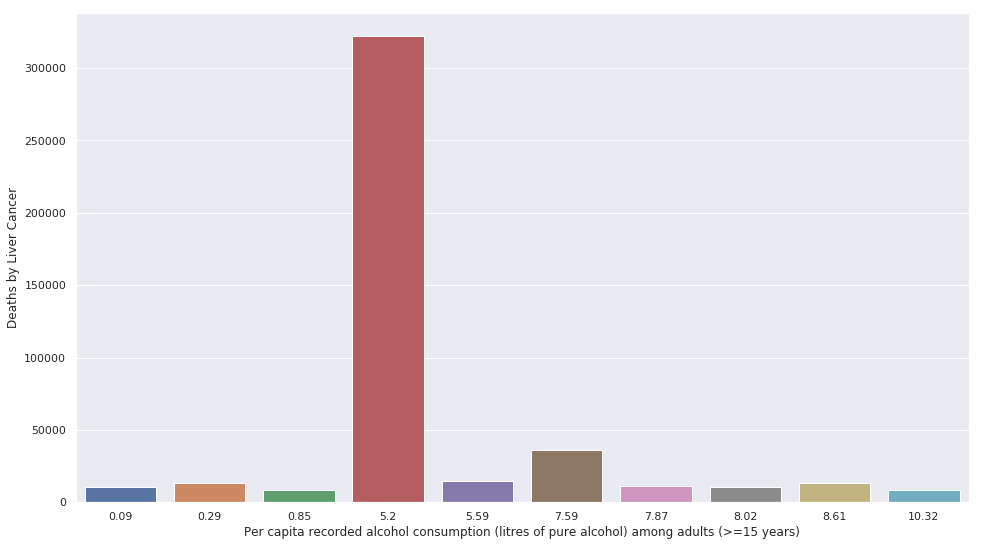

```python
plt.figure(figsize=(16,9))
# figure ration 16:9
sns.set() # for style
sns.barplot(y=df_liver_cancer_analysis['Deaths by Liver Cancer'],x=df_liver_cancer_analysis['Per capita recorded alcohol consumption (litres of pure alcohol) among adults (>=15 years)'])
```

## Conclusion:

### Out of 10 countries with highest deaths due to liver cancer, 7 countries are the one's whos Per capita consumption of Alcohol is more than that of World's average.

## Finding 3: Considering a dataset of countries with highest rate of adult literate female, is this rate consistent with rate of youth literate female? If yes then it means that all the female literate youths are getting converted to female literate adults.

```python
df_female_literacy_analysis=df[['Literacy_rate_youth_female','Literacy_rate_adult_female']].sort_values(by="Literacy_rate_adult_female",ascending=False).head(10)
df_female_literacy_analysis
```

| Country | Literacy_rate_youth_female | Literacy_rate_adult_female |
| --- | --- | --- |
| Cuba | 99.95 | 99.79 |
| Estonia | 99.81 | 99.76 |
| Latvia | 99.78 | 99.71 |
| Lithuania | 99.74 | 99.65 |
| Slovenia | 99.88 | 99.64 |
| Belarus | 99.83 | 99.42 |
| Kazakhstan | 99.87 | 99.29 |
| Russia | 99.77 | 99.23 |
| Tajikistan | 99.85 | 99.22 |
| Ukraine | 99.83 | 99.17 |

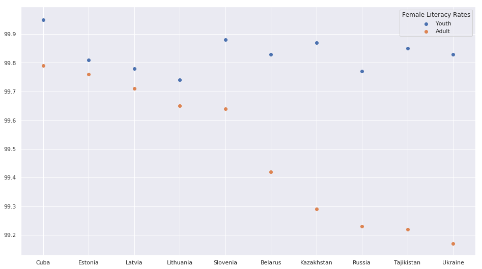

```python
plt.figure(figsize=(16,9))
plt.scatter(x=df_female_literacy_analysis.index,y='Literacy_rate_youth_female', data=df_female_literacy_analysis)
plt.scatter(x=df_female_literacy_analysis.index,y='Literacy_rate_adult_female', data=df_female_literacy_analysis)
plt.legend(['Youth','Adult'], title="Female Literacy Rates")
plt.show()
```

## Conclusion:

### We notice a pattern that all the 10 countries with highest female adult literacy rates, the female youth literacy rate is always higher.

### It implies that the all the female youths do not proceed for higher education.